# Global Terrorism Prediction

Yuan Xiang, Jingyu Gao, Lipei Tao

5/8/2017

## Objective

Analyses of terrorist groups and incidents have begun to recognize the evolutionary nature of terrorism, as well as its ability to adapt to counter-terrorism tactics. This project is intended to predict the clusters of terrorist attack using attack type, weapon type, target type, suicide dummy, month. The analysis is performed on 4 countries that have the most frequent attacks: Iraq, Afghanistan, Pakistan, India.

## Data Used

Our data is the Global Terrorism Database compiled by the University of Maryland. It collects information about each terrorist attack reported by governments around the world since 1970. The cleaned data has 20,263 records. Key variables of this dataset include: 1. Types of attack: bombing, kidnapping, etc 2. Types of weapon used in the attack: Handgun, Automatic Weapon, TNT, etc. 3. Time: month 4. Countries: Afghanistan, Iraq, India, Pakistan 5. Suicide: use suicide attack or not 6. Types of targets: civilian, government agencies, military bases, etc 7. Geographic locations: longitude, latitude

## Data Preparation and Cleaning

```r
# load data
load("/Users/yuanxiang/Documents/Project/global-terrorism/data/globalterror.RData")

project_data <- globalterror
new <- c("eventid","country_txt", "latitude","longitude","attacktype1", "targtype1",
         "region", "weaptype1","imonth",
          "suicide","gname","guncertain1","doubtterr" )

tocluster.data <- project_data[new]
head(tocluster.data)
```

```
      eventid country_txt latitude longitude attacktype1 targtype1 region
1 2.01201e+11    Pakistan 30.20942  67.01801           3         1      6
2 2.01201e+11       Kenya -0.45612  39.64612           2         1     11
3 2.01201e+11    Pakistan 28.63612  69.18646           3         4      6
4 2.01201e+11       Kenya -0.45612  39.64612           2         1     11
5 2.01201e+11    Pakistan 28.46667  67.28333           6        14      6
6 2.01201e+11    Pakistan 34.76172  71.32472           3        17      6
  weaptype1 imonth suicide                        gname guncertain1
1         6      1       0                      Unknown           0
2         6      1       0                   Al-Shabaab           1
3         6      1       0 Baloch Republican Army (BRA)           0
4         6      1       0                   Al-Shabaab           1
5         5      1       0                      Unknown           0
6         6      1       0                      Unknown           0
  doubtterr
1         0
2         0
3         1
4         0
5         0
6         0
```

```r
# clean data
tocluster.data <- tocluster.data[tocluster.data$guncertain1 == 0 | tocluster.data$doubtterr == 0,]
tocluster.data <- tocluster.data[tocluster.data$gname != "Unknown",]
tocluster.data <- tocluster.data[!tocluster.data$weaptype1 %in% c(12, 13),]
tocluster.data <- tocluster.data[tocluster.data$attacktype1 != 9, ]
tocluster.data <- tocluster.data[!tocluster.data$targtype1 %in% c(13,20), ]

# Convert data into categorical variables
tocluster.data[, 5:ncol(tocluster.data)] <- lapply(tocluster.data[, 5:ncol(tocluster.data)], as.factor)

str(tocluster.data)
```

```
Classes 'tbl_df', 'tbl' and 'data.frame':   20263 obs. of  13 variables:
 $ eventid    : num  2.01e+11 2.01e+11 2.01e+11 2.01e+11 2.01e+11 ...
 $ country_txt: chr  "Kenya" "Pakistan" "Kenya" "Afghanistan" ...
 $ latitude   : num  -0.456 28.636 -0.456 32.397 30.489 ...
 $ longitude  : num  39.6 69.2 39.6 64.5 -87.2 ...
 $ attacktype1: Factor w/ 8 levels "1","2","3","4",..: 2 3 2 3 7 3 3 2 3 3 ...
 $ targtype1  : Factor w/ 20 levels "1","2","3","4",..: 1 4 1 4 5 13 13 13 4 4 ...
 $ region     : Factor w/ 12 levels "1","2","3","4",..: 11 6 11 6 1 6 6 11 6 6 ...
 $ weaptype1  : Factor w/ 9 levels "1","2","5","6",..: 4 4 4 4 6 4 4 3 4 4 ...
 $ imonth     : Factor w/ 12 levels "1","2","3","4",..: 1 1 1 1 1 1 1 1 1 1 ...
 $ suicide    : Factor w/ 2 levels "0","1": 1 1 1 1 1 1 1 1 1 1 ...
 $ gname      : Factor w/ 569 levels "313 Brigade (Syria)",..: 47 99 47 498 529 541 498 460 498 498 ...
 $ guncertain1: Factor w/ 2 levels "0","1": 2 1 2 1 1 2 1 1 1 1 ...
 $ doubtterr  : Factor w/ 2 levels "0","1": 1 2 1 2 1 1 1 2 2 2 ...
```

## Hierarchical Cluster

### Write Functions to perform hierarchical clusters

```r
#HC Object function
hc.object <- function(country, featurelist){
  # Args:
      #       country: country dataframe
      #       featurelist: intput features vectors
      #
  # Returns:
      #       A HC object

  library(cluster)
  country.gower <- daisy(country[featurelist], metric = "gower")
  country.gmat <- as.matrix(country.gower)
  hc <- hclust(country.gower, method="ward.D")
  return(hc)
}

#Group function
set.groups <- function(hc.object, klusters){
  # Args:
      #       hc.object: HC object
      #       kclusters: the numbers of clusters
      #
  # Returns:
      #       Groups for the passed HC object
  library(cluster)
  groups <- cutree(hc.object, k = klusters)
  return(groups)
}

#Maps function
draw.map <- function(country, groups){
  # Args:
      #       country: country dataframe
      #       groups: clusters given by hclust function
      #
  # Returns:
      #       Map for the countries passed in
  library(maps)
  country.map <- map("world", region = country, interior=FALSE)
  country.map <- map("world",boundary=FALSE,col="black",add=TRUE)
  country.map <- points(eval(parse(text=country))$longitude, eval(parse(text=country))$latitude, pch = 19, cex=0.3,col=factor(groups))
  legend("bottomright", bty = "n", legend=levels(factor(groups)),
         cex = 1,  x.intersp=0, xjust=0, yjust=0, text.col=seq_along(levels(factor(groups))))
  return(country.map)
}
```

### Apply Hierarchical Clustering

```
[1] "Iraq"
```

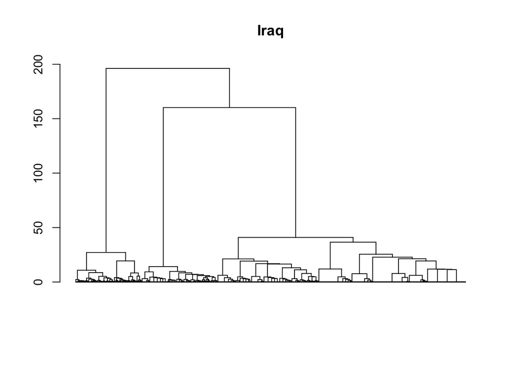

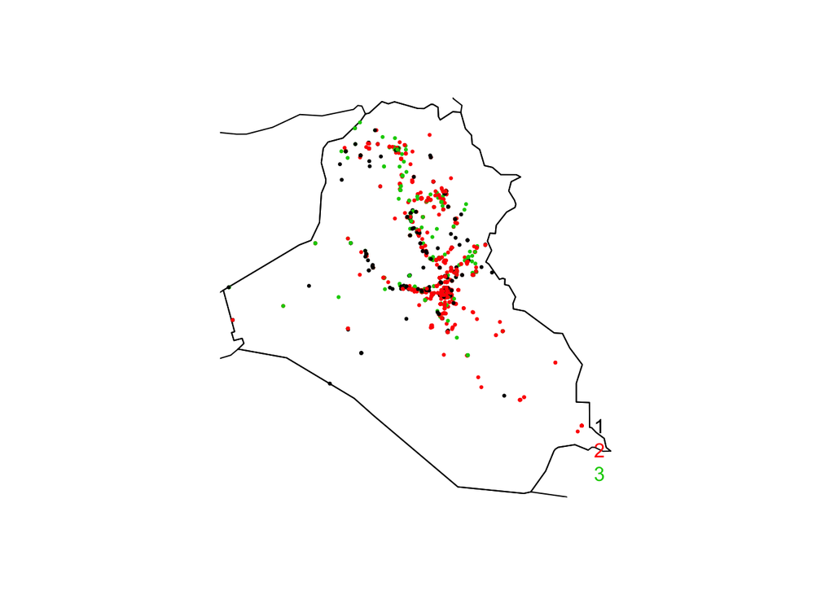

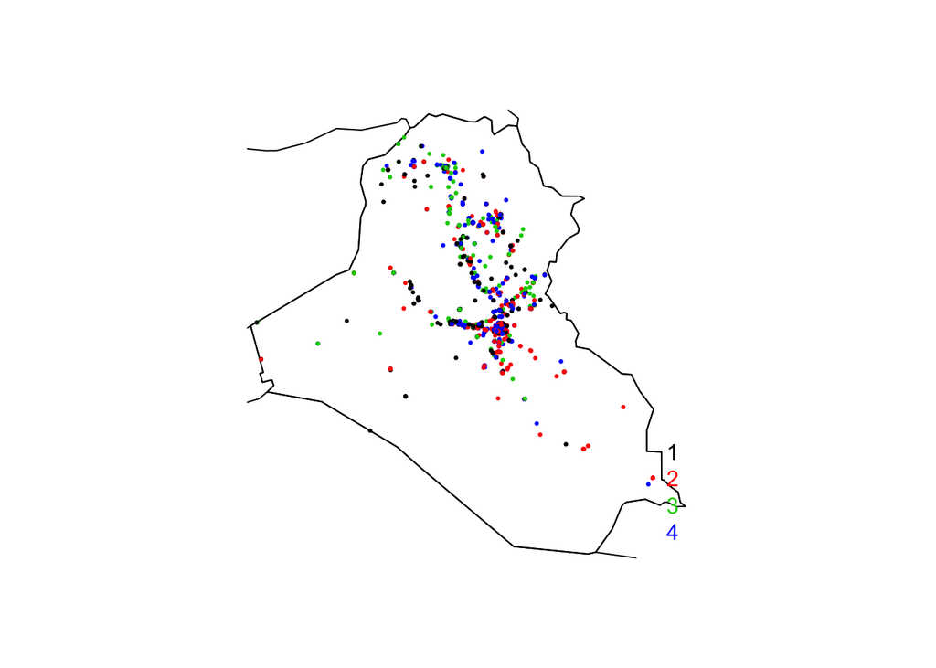

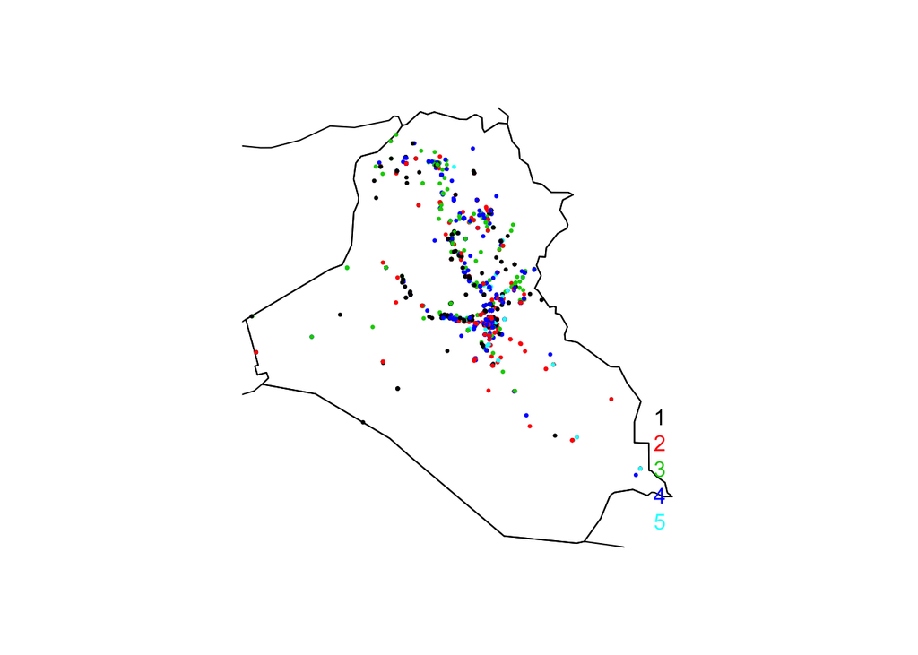

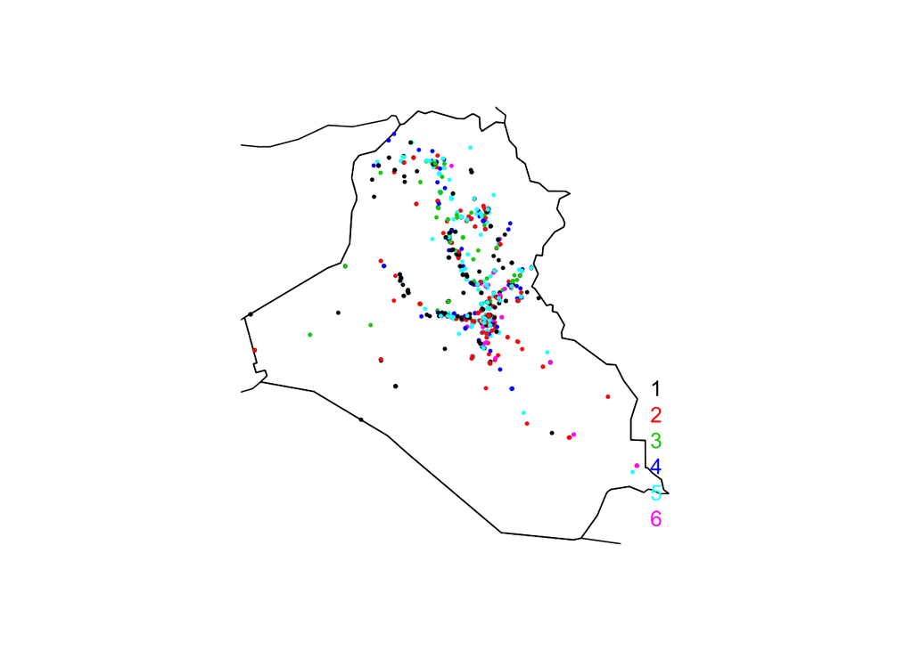

```
[1] "Pakistan"
```

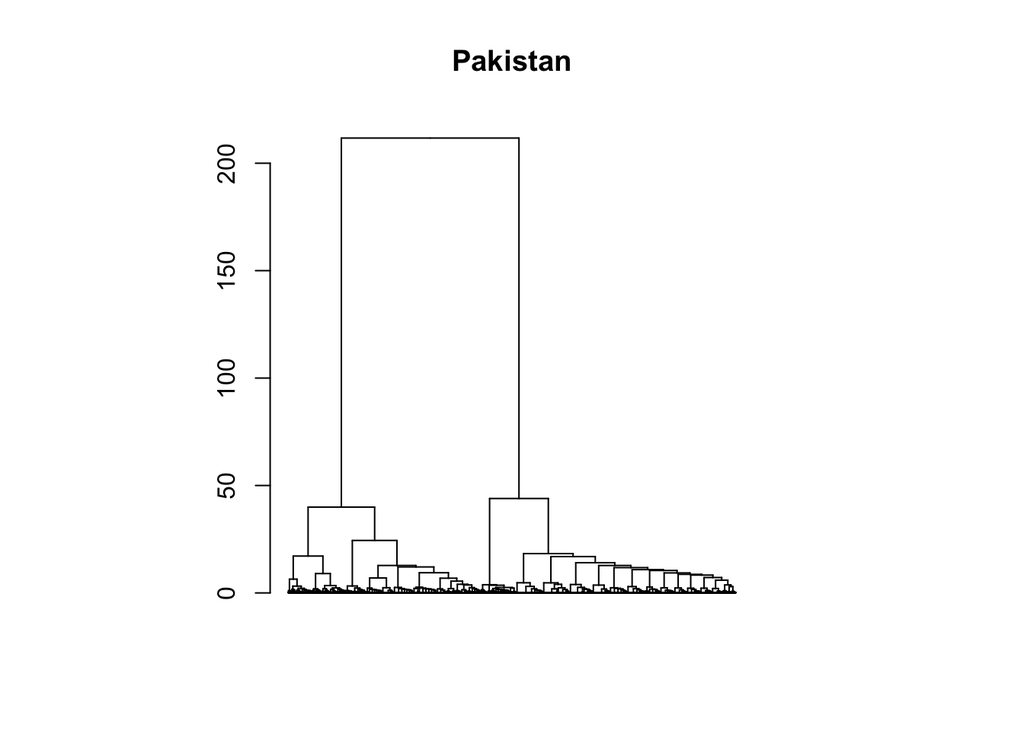

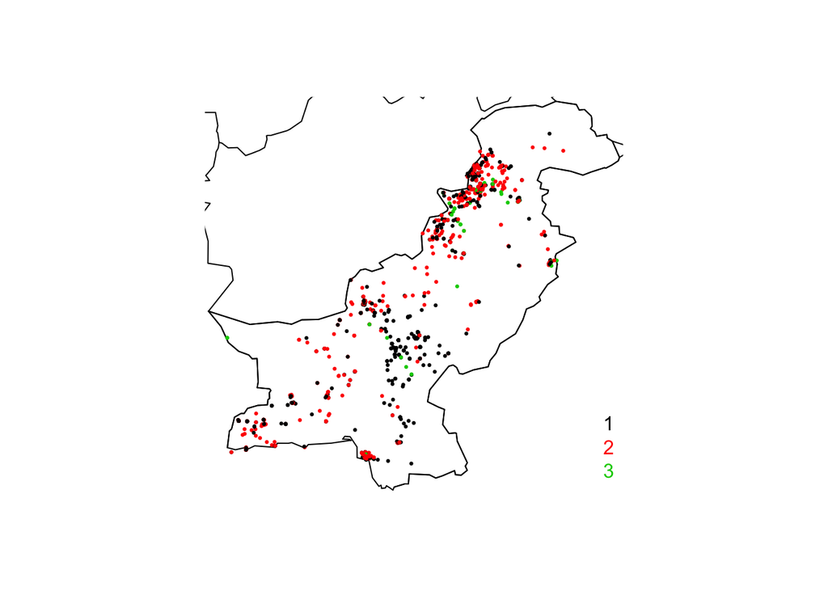

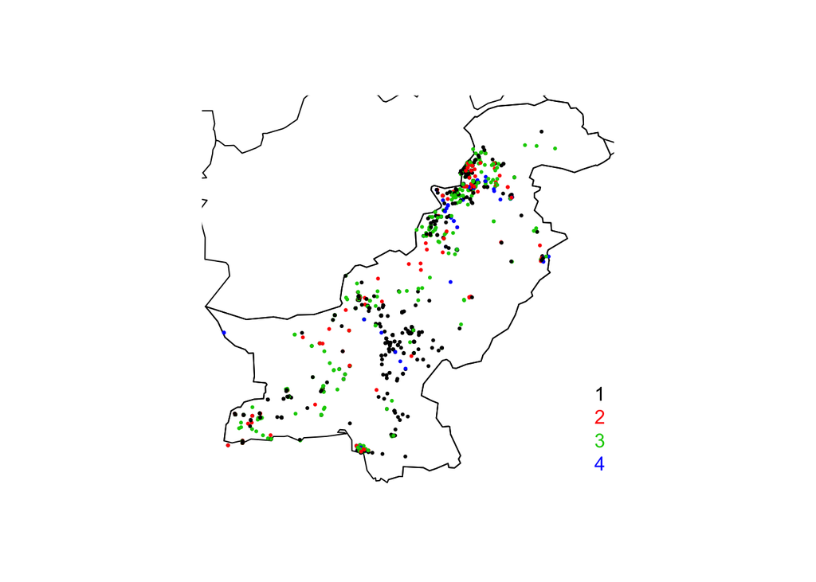

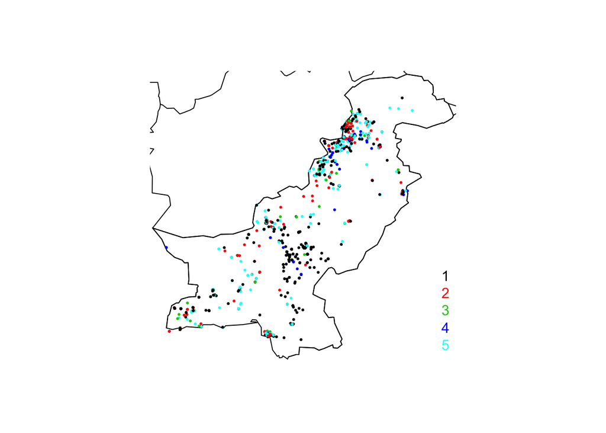

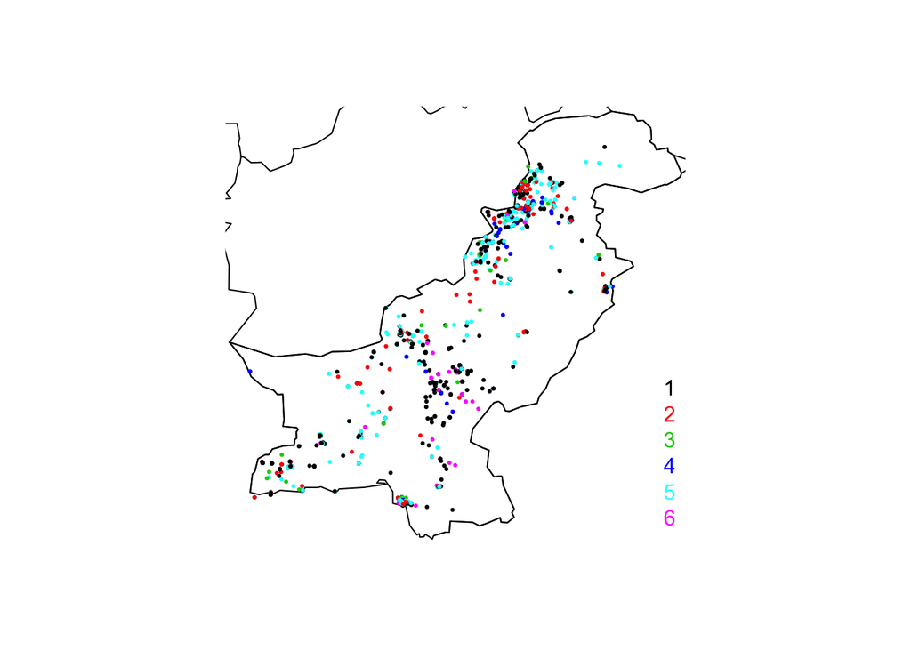

```
[1] "Afghanistan"
```

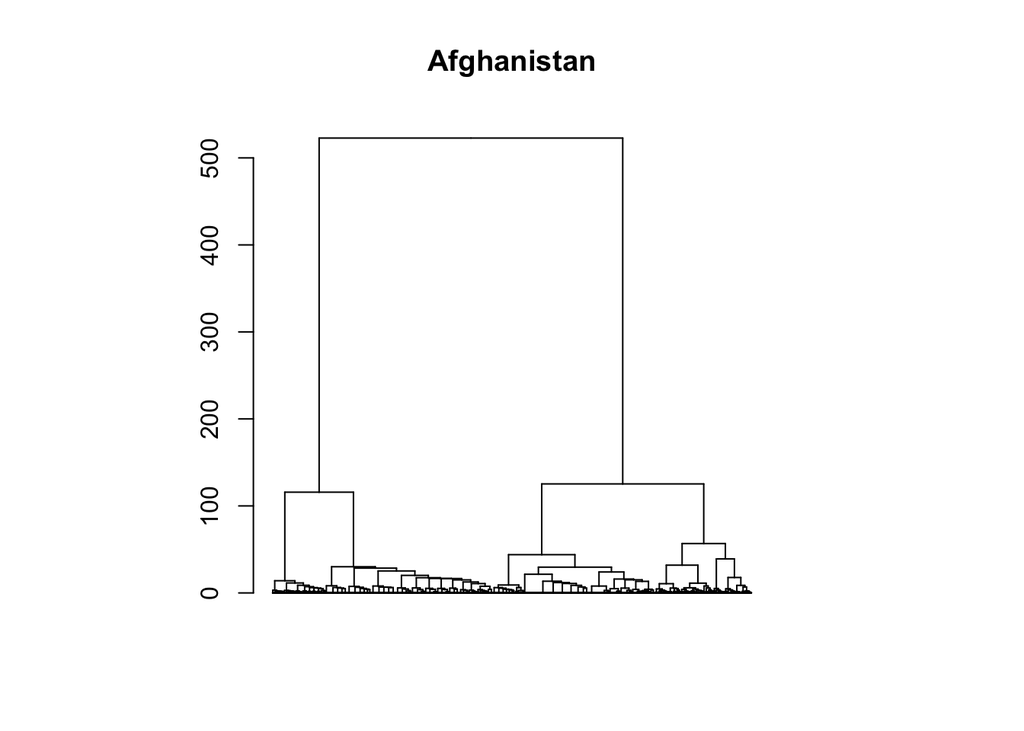

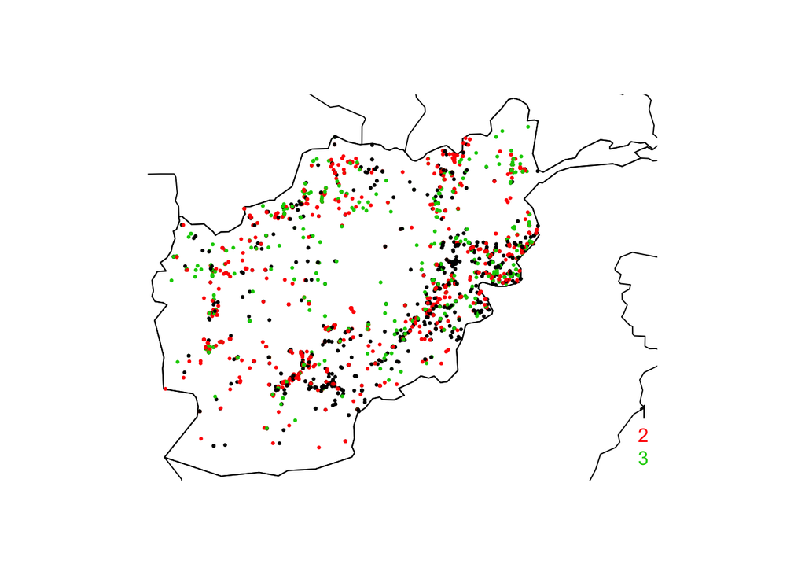

[8 more figures not shown]

```r
# Create country data frames
Iraq <- tocluster.data[tocluster.data$country_txt=="Iraq",]
Pakistan <- tocluster.data[tocluster.data$country_txt=="Pakistan",]
Afghanistan <- tocluster.data[tocluster.data$country_txt=="Afghanistan",]
India <- tocluster.data[tocluster.data$country_txt=="India",]
feature.list <- c("attacktype1", "targtype1", "weaptype1","imonth","suicide")

### Apply hierarchical clustering methods
#Loop through countries and numbers of k
country.list <- c("Iraq", "Pakistan", "Afghanistan", "India")
k.list <- c(3:6)

for(i in country.list){
  df.hc <- hc.object(eval(parse(text=i)), feature.list)
  print(paste(i))
  assign(paste0(i,".hc"), df.hc)
  df.plot <- plot(as.dendrogram(eval(parse(text = paste0(i,".hc")))), main = i, leaflab = "none")
  dev.print(pdf, paste0(i,".hc",".pdf"))
  assign(paste0(i,".plot"), df.plot)
  carto.data <- cbind(eval(parse(text=i))$longitude, eval(parse(text=i))$latitude)
  for(j in k.list){
    df.k <- set.groups(eval(parse(text = paste0(i,".hc"))), j)
    assign(paste0(i,".k", j), df.k)
    draw.map(i, eval(parse(text = paste0(i,".k", j))))
    dev.print(pdf, paste0(i,".map", ".k",j,".pdf"))
    carto.data <- cbind(carto.data, eval(parse(text = paste0(i,".k", j))))
  }
  assign(paste0(i, ".carto"), carto.data)
}
```

rename the output matrix

```r
# rename the output matrix
colnames(Afghanistan.carto) <- c("longitude","latitude","k3","k4","k5","k6")
colnames(India.carto) <- c("longitude","latitude","k3","k4","k5","k6")
colnames(Iraq.carto) <- c("longitude","latitude","k3","k4","k5","k6")
colnames(Pakistan.carto) <- c("longitude","latitude","k3","k4","k5","k6")
colnames(carto.data) <- c("longitude","latitude","k3","k4","k5","k6")
```

### Prepare dataframe for the summary table of clusters

```r
# Convert output to dataframe and rename the output
Afghanistan.carto <- as.data.frame(Afghanistan.carto)
India.carto <- as.data.frame(India.carto)
Pakistan.carto <- as.data.frame(Pakistan.carto)
Iraq.carto <- as.data.frame(Iraq.carto)
carto.data <- as.data.frame(carto.data)

# rename the columns
colnames(Afghanistan.carto) <- c("longitude","latitude","k3","k4","k5","k6")
colnames(India.carto) <- c("longitude","latitude","k3","k4","k5","k6")
colnames(Iraq.carto) <- c("longitude","latitude","k3","k4","k5","k6")
colnames(Pakistan.carto) <- c("longitude","latitude","k3","k4","k5","k6")
colnames(carto.data) <- c("longitude","latitude","k3","k4","k5","k6")

# append groups to the country dataframe(k = 3)
Afghanistan.group <- cbind(Afghanistan[feature.list], Afghanistan.carto$k3)
India.group <- cbind(India[feature.list], India.carto$k3)
Pakistan.group <- cbind(Pakistan[feature.list], Pakistan.carto$k3)
Iraq.group <- cbind(Iraq[feature.list], Iraq.carto$k3)

# rename cluster column
colnames(Afghanistan.group)[ncol(Afghanistan.group)] <- c("group")
colnames(India.group)[ncol(India.group)] <- c("group")
colnames(Pakistan.group)[ncol(Pakistan.group)] <- c("group")
colnames(Iraq.group)[ncol(Iraq.group)] <- c("group")
```

### What do each clusters represent

```r
# Summary of clusters
# Create mode function
Mode <- function(x){
  ux <- unique(x)
  ux[which.max(tabulate(match(x, ux)))]
}

# Get mode features for each clusters
overview.Iraq <- aggregate(Iraq.group, list(Iraq.group$group), Mode)
overview.India <- aggregate(India.group, list(India.group$group), Mode)
overview.Pakistan <- aggregate(Pakistan.group, list(Pakistan.group$group), Mode)
overview.Afghanistan <- aggregate(Afghanistan.group, list(Afghanistan.group$group), Mode)
```

Take a look at the result

```r
overview.Afghanistan
```

```
  Group.1 attacktype1 targtype1 weaptype1 imonth suicide group
1       1           3         3         6      5       0     1
2       2           2         3         5      5       0     2
3       3           6         2         5      8       0     3
```

```r
overview.India
```

```
  Group.1 attacktype1 targtype1 weaptype1 imonth suicide group
1       1           3         3         6      4       0     1
2       2           7         1         8      6       0     2
3       3           2        14         5      4       0     3
```

```r
overview.Iraq
```

```
  Group.1 attacktype1 targtype1 weaptype1 imonth suicide group
1       1           3         4         6     12       1     1
2       2           3        14         6      7       0     2
3       3           2         4         5      6       0     3
```

```r
overview.Pakistan
```

```
  Group.1 attacktype1 targtype1 weaptype1 imonth suicide group
1       1           3         4         6      2       0     1
2       2           2         4         5      5       0     2
3       3           3         3         6      2       1     3
```

### Get Top 3 Frequent Features

Iraq

```r
library(plyr)

# Top3 frequent features for Iraq
top3.Iraq <- data.frame(row.names = 1:3)
for (f in feature.list){
  d <-ddply(Iraq.group, .(group), summarize,
            All=length(group),
            Variable = paste0(f),
            frequency = paste(paste(sort(unique(eval(parse(text = f))))[1:3],sort(table(eval(parse(text = f)))[table(eval(parse(text = f)))>0], decreasing = T)[1:3],sep="="),collapse=","))
  top3.Iraq <- cbind(top3.Iraq, d)
}
top3.Iraq
```

```
  group  All    Variable       frequency group  All  Variable
1     1  461 attacktype1   1=445,3=7,5=6     1  461 targtype1
2     2 1508 attacktype1  3=1502,5=5,6=1     2 1508 targtype1
3     3  403 attacktype1 1=244,2=85,4=55     3  403 targtype1
          frequency group  All  Variable          frequency group  All
1  1=204,2=100,3=66     1  461 weaptype1  6=461,NA=NA,NA=NA     1  461
2 1=776,2=236,3=162     2 1508 weaptype1 6=1508,NA=NA,NA=NA     2 1508
3  1=107,2=105,3=95     3  403 weaptype1    5=316,6=58,8=15     3  403
  Variable         frequency group  All Variable          frequency
1   imonth    1=49,2=46,3=46     1  461  suicide  1=461,NA=NA,NA=NA
2   imonth 1=212,2=198,3=148     2 1508  suicide 0=1508,NA=NA,NA=NA
3   imonth    1=60,2=50,3=40     3  403  suicide    0=402,1=1,NA=NA
```

Afghanistan

```r
# Top 3 frequent features for Afghanistan
top3.Afghanistan <- data.frame(row.names = 1:3)
for (f in feature.list){
  d <-ddply(Afghanistan.group, .(group), summarize,
            All=length(group),
            Variable = paste0(f),
            frequency = paste(paste(sort(unique(eval(parse(text = f))))[1:3],sort(table(eval(parse(text = f)))[table(eval(parse(text = f)))>0], decreasing = T)[1:3],sep="="),collapse=","))
  top3.Afghanistan <- cbind(top3.Afghanistan, d)
}
top3.Afghanistan
```

```
  group  All    Variable        frequency group  All  Variable
1     1 1548 attacktype1   3=1540,5=5,6=3     1 1548 targtype1
2     2 1131 attacktype1  1=1110,2=13,4=5     2 1131 targtype1
3     3  670 attacktype1 1=253,2=220,4=98     3  670 targtype1
          frequency group  All  Variable          frequency group  All
1 1=473,2=429,3=352     1 1548 weaptype1 6=1548,NA=NA,NA=NA     1 1548
2 1=678,2=263,3=105     2 1131 weaptype1   5=1129,9=2,NA=NA     2 1131
3 1=199,2=183,3=125     3  670 weaptype1   2=355,5=173,6=94     3  670
  Variable         frequency group  All Variable          frequency
1   imonth 1=186,2=160,3=153     1 1548  suicide 0=1166,1=382,NA=NA
2   imonth 1=174,2=132,3=111     2 1131  suicide 0=1131,NA=NA,NA=NA
3   imonth    1=87,2=75,3=68     3  670  suicide   0=649,1=21,NA=NA
```

Pakistan

```r
# Top 3 frequent features for Pakistan
top3.Pakistan <- data.frame(row.names = 1:3)
for (f in feature.list){
  d <-ddply(Pakistan.group, .(group), summarize,
            All=length(group),
            Variable = paste0(f),
            frequency = paste(paste(sort(unique(eval(parse(text = f))))[1:3],sort(table(eval(parse(text = f)))[table(eval(parse(text = f)))>0], decreasing = T)[1:3],sep="="),collapse=","))
  top3.Pakistan <- cbind(top3.Pakistan, d)
}
top3.Pakistan
```

```
  group All    Variable        frequency group All  Variable
1     1 739 attacktype1    1=726,2=8,3=3     1 739 targtype1
2     2 648 attacktype1 1=434,2=110,4=75     2 648 targtype1
3     3 122 attacktype1   1=108,3=11,5=2     3 122 targtype1
          frequency group All  Variable         frequency group All
1  1=181,2=131,3=91     1 739 weaptype1 6=739,NA=NA,NA=NA     1 739
2 1=155,2=141,3=141     2 648 weaptype1  2=523,5=108,6=10     2 648
3    1=30,2=25,3=16     3 122 weaptype1 6=122,NA=NA,NA=NA     3 122
  Variable      frequency group All Variable         frequency
1   imonth 1=97,2=91,3=78     1 739  suicide   0=738,1=1,NA=NA
2   imonth 1=66,2=65,3=65     2 648  suicide   0=647,1=1,NA=NA
3   imonth 1=17,2=16,3=14     3 122  suicide 1=122,NA=NA,NA=NA
```

India

```r
# Top 3 frequent features for India

top3.India <- data.frame(row.names = 1:3)
for (f in feature.list){
  d <-ddply(India.group, .(group), summarize,
            All=length(group),
            Variable = paste0(f),
            frequency = paste(paste(sort(unique(eval(parse(text = f))))[1:3],sort(table(eval(parse(text = f)))[table(eval(parse(text = f)))>0], decreasing = T)[1:3],sep="="),collapse=","))
  top3.India <- cbind(top3.India, d)
}
top3.India
```

```
  group All    Variable        frequency group All  Variable
1     1 681 attacktype1   1=638,2=34,3=5     1 681 targtype1
2     2 137 attacktype1    1=131,5=3,6=1     2 137 targtype1
3     3 854 attacktype1 1=467,2=245,4=62     3 854 targtype1
          frequency group All  Variable       frequency group All Variable
1  1=224,2=138,3=75     1 681 weaptype1 5=680,6=1,NA=NA     1 681   imonth
2    1=60,2=30,3=17     2 137 weaptype1   5=135,8=1,9=1     2 137   imonth
3 1=279,2=222,3=117     3 854 weaptype1 5=725,6=91,8=17     3 854   imonth
        frequency group All Variable         frequency
1  1=89,2=68,3=67     1 681  suicide   0=674,1=7,NA=NA
2  1=25,2=17,3=15     2 137  suicide 0=137,NA=NA,NA=NA
3 1=101,2=93,3=89     3 854  suicide 0=854,NA=NA,NA=NA
```

Combine 4 countries together

```r
top3.feature <- data.frame()
top3.feature <- rbind(top3.Iraq, top3.Pakistan, top3.Afghanistan, top3.India)

# Add and rename country columns
top3.feature <- cbind(top3.feature, rep(country.list, each = 3))
top3.feature <- top3.feature[c(17, 1:16)]
colnames(top3.feature)[1] <- "Country"
```

Take a look at the final output

```r
top3.feature
```

```
   Country group.1  All    Variable        frequency group.2 All.1
1        1       1  461 attacktype1    1=445,3=7,5=6       1   461
2        2       2 1508 attacktype1   3=1502,5=5,6=1       2  1508
3        3       3  403 attacktype1  1=244,2=85,4=55       3   403
4        1       1  739 attacktype1    1=726,2=8,3=3       1   739
5        2       2  648 attacktype1 1=434,2=110,4=75       2   648
6        3       3  122 attacktype1   1=108,3=11,5=2       3   122
7        1       1 1548 attacktype1   3=1540,5=5,6=3       1  1548
8        2       2 1131 attacktype1  1=1110,2=13,4=5       2  1131
9        3       3  670 attacktype1 1=253,2=220,4=98       3   670
10       1       1  681 attacktype1   1=638,2=34,3=5       1   681
11       2       2  137 attacktype1    1=131,5=3,6=1       2   137
12       3       3  854 attacktype1 1=467,2=245,4=62       3   854
   Variable.1       frequency.1 group.3 All.2 Variable.2
1   targtype1  1=204,2=100,3=66       1   461  weaptype1
```

[output cut: 24 more lines]